# Homework 10

## Part I

1. c
2. a
3. c
4. d
5. a
6. b
7. d
8. c
9. d
10. c
11. b
12. d
13. c
14. b
15. a

## Problem 1

### 1.1

$\mathcal{P}_{2000,2001}^{L}=.8636,\mathcal{P}_{2000,2002}^{L}=.6136\Rightarrow CPI: 100, 86.36, 61.36$

### 1.2

$\mathcal{P}_{2000,2001}^{L}=.8636,\mathcal{P}_{2000,2001}^{P}=.9167,\mathcal{P}_{2001,2002}^{L}=.7727,\mathcal{P}_{2001,2002}^{P}=.8571$ $\Rightarrow\mathcal{P}_{2000,2001}^{F}=.8898,\mathcal{P}_{2001,2002}^{F}=.8138,\mathcal{P}_{2000,2001}^{C}=.8898,\mathcal{P}_{2000,2002}^{C}=.7241$ $\Rightarrow CPI: 100, 88.98, 72.41$

### 1.3

GDP: 22000, 16500, 12000

### 1.4

RGDP: 22000, 18000, 14000[^1]

### 1.5

RGDP: 13500[^2], 12750, 12000

### 1.6

$\mathcal{Q}_{2000,2001}^{L}=.8182,\mathcal{Q}_{2000,2001}^{P}=.8684,\mathcal{Q}_{2001,2002}^{L}=.8485,\mathcal{Q}_{2001,2002}^{P}=.9412$ $\Rightarrow\mathcal{Q}_{2000,2001}^{F}=.8429,\mathcal{Q}_{2001,2002}^{F}=.8936,\mathcal{Q}_{2000,2001}^{C}=.8429,\mathcal{Q}_{2000,2002}^{C}=.7532$ $\Rightarrow RGDP: 22000, 18543.8, 16570.4$[^3]

### 1.7

RGDP: 15932.02[^4], 13428.83[^5], 12000

### 1.8

GDP Deflator: 100, 91.67, 85.71

### 1.9

GDP Deflator: 100, 88.98, 72.42

## Problem 2

### 2.1

$\left(\frac{15676}{10642}\right)^{\frac{1}{10}}-1=.039=3.9\%$

### 2.2

Real GDP in 2002: $10642\times100/92.2=11542.3$

Real GDP in 2012: $15676\times100/115.4=13584.06$

Annual growth rate: $\left(\frac{13584.06}{11542.3}\right)^{\frac{1}{10}}-1=.016=1.6\%$

## Problem 1

### 1.1

2009

### 1.2

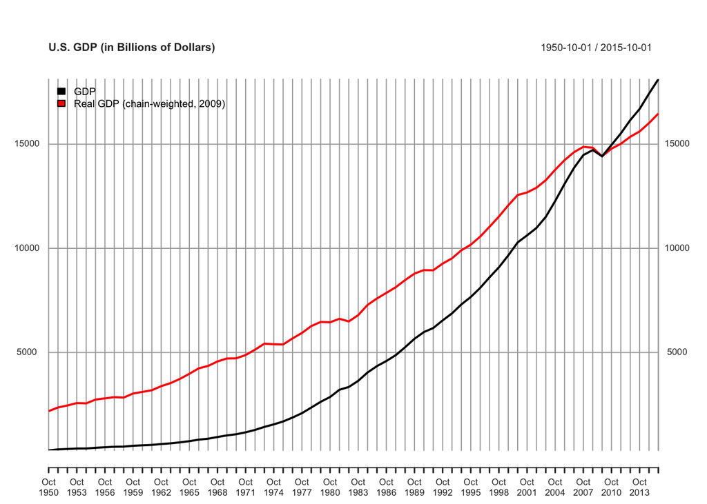

```r
library(quantmod)
t = "1950-01-01/2015-10-01"

gdpQ = getSymbols('GDP',src='FRED',auto.assign=FALSE)
rgdpQ = getSymbols('GDPC1',src='FRED',auto.assign=FALSE)

gdpQ = gdpQ[t]
rgdpQ = rgdpQ[t]

# convert quarterly data into annual data
gdp = apply.yearly(gdpQ,mean)
rgdp = apply.yearly(rgdpQ,mean)

data = cbind(gdp,rgdp)
colnames(data) <- c("GDP","Real GDP (chain-weighted, 2009)")

plot(data,legend.loc='topleft',auto.legend=TRUE,main="U.S. GDP (in Billions of Dollars)")
```

### 1.3

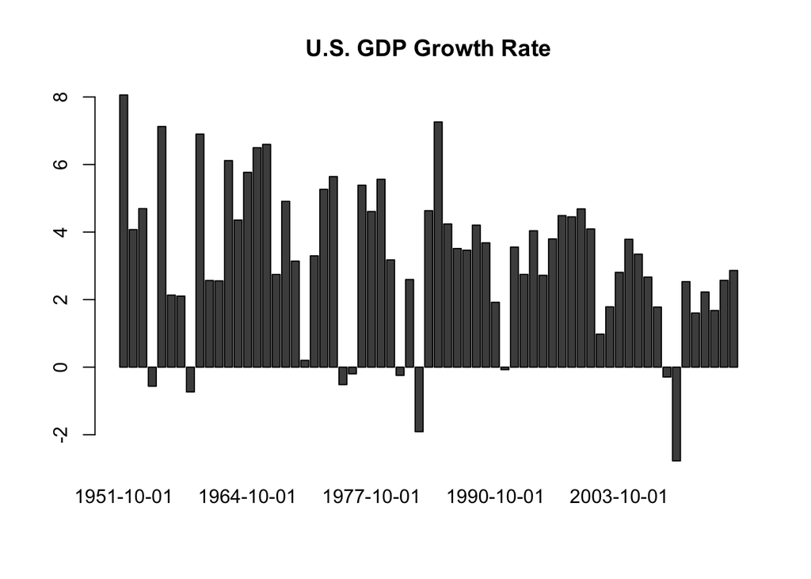

```r
grgdp = (rgdp/lag(rgdp)-1)*100
grgdp = grgdp[-1,] #get rid of the first row, which is NA
barplot(grgdp,main="U.S. GDP Growth Rate")
```

### 1.4

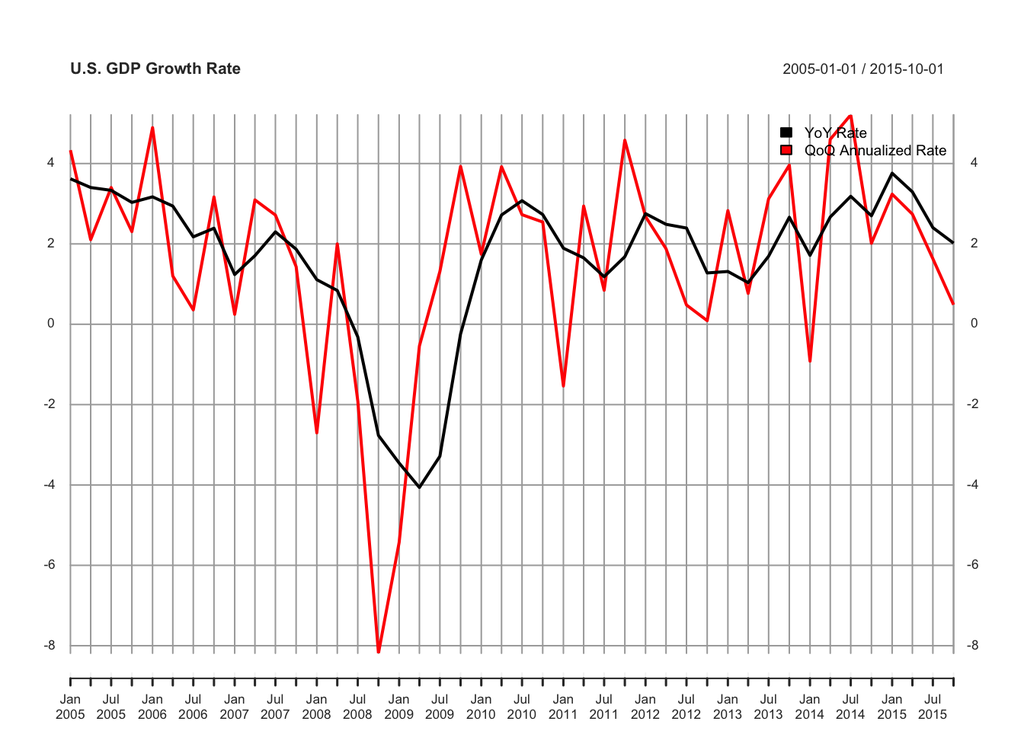

```r
grgdpQ_yoy = (rgdpQ/lag(rgdpQ,4)-1)*100
grgdpQ_qoq = ((rgdpQ/lag(rgdpQ))^4-1)*100
data = cbind(grgdpQ_yoy,grgdpQ_qoq)
colnames(data) <- c('YoY Rate','QoQ Annualized Rate')
t = "2005-01-01/2015-10-01"
plot(data[t],legend.loc='topright',auto.legend=TRUE,main='U.S. GDP Growth Rate')
```

### 1.5

2009.Q2

### 1.6

2008.Q4

### 1.7

Q-on-Q annualized rate

## Problem 2

### 2.1

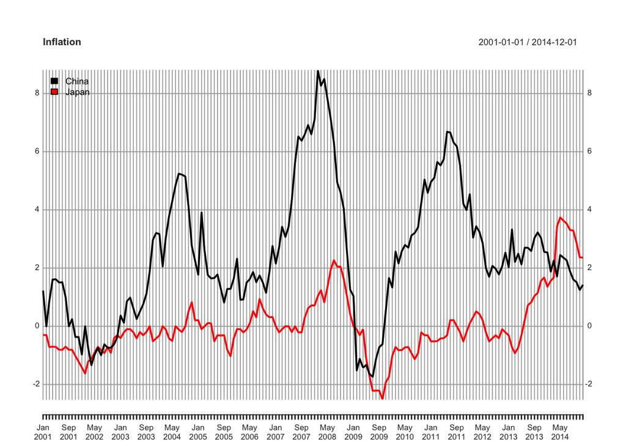

```r
t = "2000-01-01/2014-12-01"

china = getSymbols('CHNCPIALLMINMEI',src='FRED',auto.assign=FALSE)
japan = getSymbols('JPNCPIALLMINMEI',src='FRED',auto.assign=FALSE)

china = china[t]
japan = japan[t]

# calculate yoy inflation rate
pi.china = (china/lag(china,12)-1)*100
pi.japan = (japan/lag(japan,12)-1)*100

pi.china = pi.china[-c(1:12),] #get rid of the first 12 rows, which are NA
pi.japan = pi.japan[-c(1:12),] #get rid of the first 12 rows, which are NA

data = cbind(pi.china,pi.japan)
colnames(data) <- c("China","Japan")

plot(data,legend.loc='topleft',auto.legend=TRUE,main="Inflation")
```

### 2.2

```r
sum(pi.japan < 0)
```

```
## [1] 102
```

### 2.3

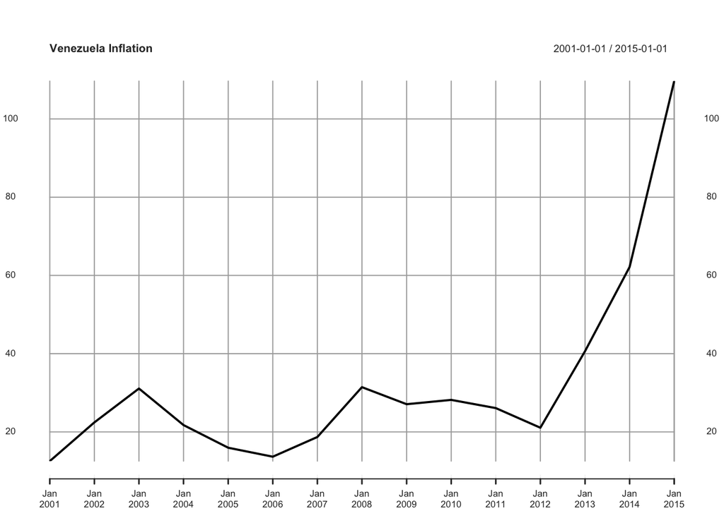

```r
t = "2001-01-01/2015-01-01"

venezuela = getSymbols('FPCPITOTLZGVEN',src='FRED',auto.assign=FALSE)

plot(venezuela[t],main="Venezuela Inflation")
```

### 2.4

```r
venezuela["2015"]
```

```
##            FPCPITOTLZGVEN
## 2015-01-01       109.6811
```

## Problem 3

### 3.1

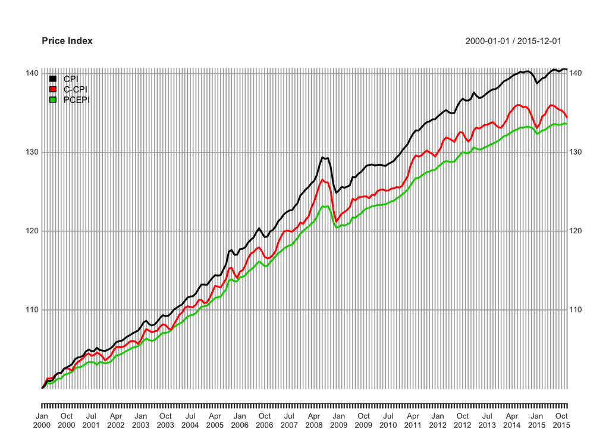

```r
t = "2000-01-01/2015-12-01"

cpi = getSymbols('CPIAUCSL',src='FRED',auto.assign=FALSE)
ccpi = getSymbols('SUUR0000SA0',src='FRED',auto.assign=FALSE)
pcepi = getSymbols('PCEPI',src='FRED',auto.assign=FALSE)

cpi = cpi[t]
ccpi = ccpi[t]
pcepi = pcepi[t]

# set 2000.01 to be base period
cpi = cpi/coredata(cpi)[1]*100
ccpi = ccpi/coredata(ccpi)[1]*100
pcepi = pcepi/coredata(pcepi)[1]*100

data = cbind(cpi,ccpi,pcepi)
colnames(data) <- c("CPI","C-CPI","PCEPI")

plot(data,legend.loc='topleft',auto.legend=TRUE,main="Price Index")
```

### 3.2

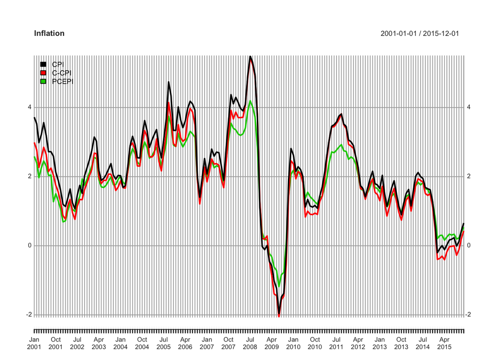

```r
pi.cpi = (cpi/lag(cpi,12)-1)*100
pi.ccpi = (ccpi/lag(ccpi,12)-1)*100
pi.pcepi = (pcepi/lag(pcepi,12)-1)*100

data = cbind(pi.cpi,pi.ccpi,pi.pcepi)
colnames(data) <- c("CPI","C-CPI","PCEPI")
data = data[-c(1:12),] #get rid of the first 12 rows, which are NA

plot(data,legend.loc='topleft',auto.legend=TRUE,main="Inflation")
```

### 3.3

On average CPI-U > C-CPI-U > PCEPI

### 3.4

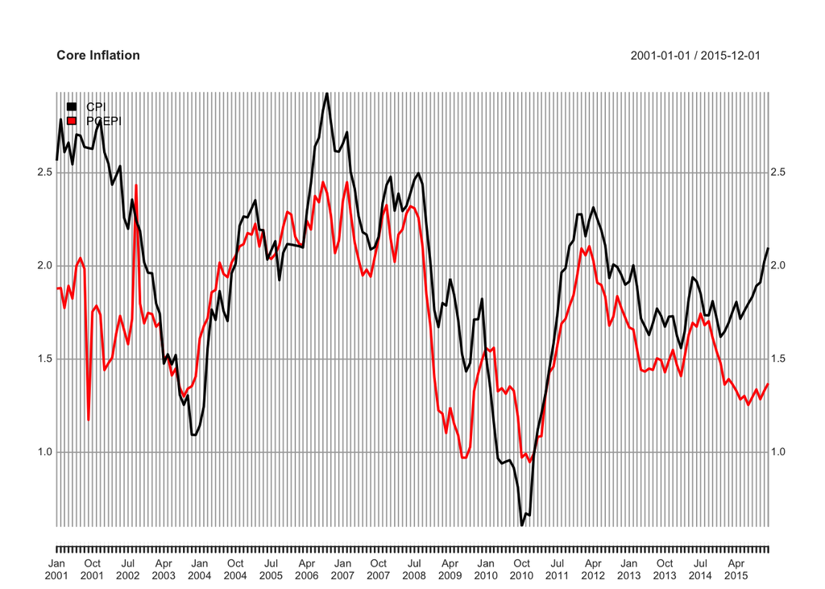

```r
t = "2000-01-01/2015-12-01"

cpicore = getSymbols('CPILFESL',src='FRED',auto.assign=FALSE)
pcepicore = getSymbols('PCEPILFE',src='FRED',auto.assign=FALSE)

cpicore = cpicore[t]
pcepicore = pcepicore[t]

pi.cpicore = (cpicore/lag(cpicore,12)-1)*100
pi.pcepicore = (pcepicore/lag(pcepicore,12)-1)*100

data = cbind(pi.cpicore,pi.pcepicore)
colnames(data) <- c("CPI","PCEPI")
data = data[-c(1:12),] #get rid of the first 12 rows, which are NA

plot(data,legend.loc='topleft',auto.legend=TRUE,main="Core Inflation")
```

### 3.4

1. higher; higher
2. lower than; higher than

### 3.6

Overall food and energy prices were falling in 2015, contributing negatively to both CPI-U and PCEPI. Altogether food and energy have a larger weight in the CPI basket than in the PCEPI, causing CPI to drop more than PCEPI in 2015. Hence even though core CPI inflation was higher than core PCEPI inflation, headline CPI inflation was lower than headline PCEPI inflation.

### 3.7

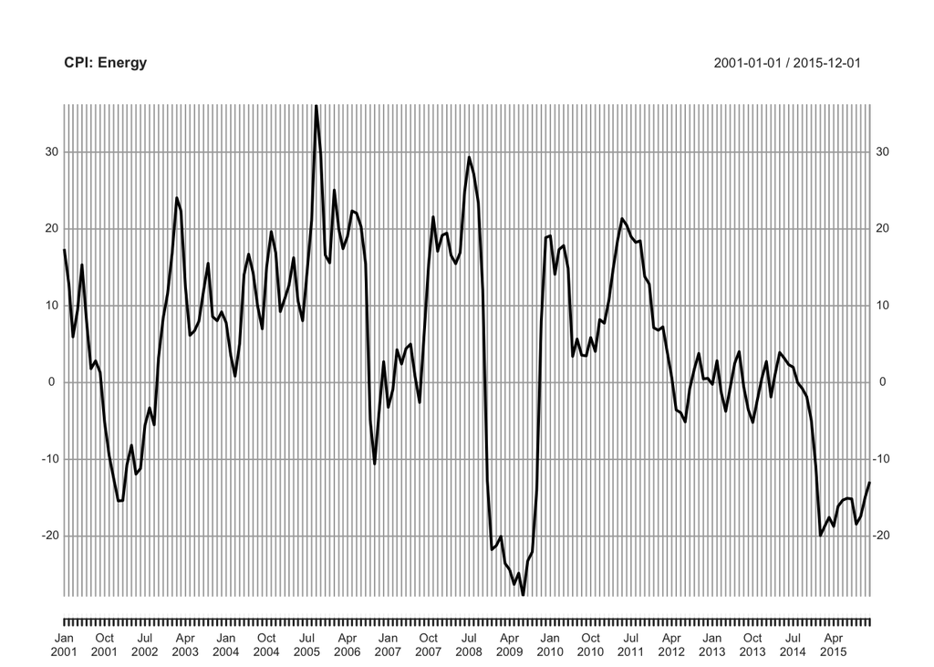

```r
energy = getSymbols('CPIENGSL',src='FRED',auto.assign=FALSE)
pi.energy = (energy/lag(energy,12)-1)*100
t = "2001-01-01/2015-12-01" # time range for inflation rate is 2001.01 - 2015.12
plot(pi.energy[t],main="CPI: Energy")
```

### 3.8

Decreasing. Average inflation rate:

```r
mean(pi.energy["2015"])
```

```
## [1] -16.6724
```

## Problem 4

### 4.1

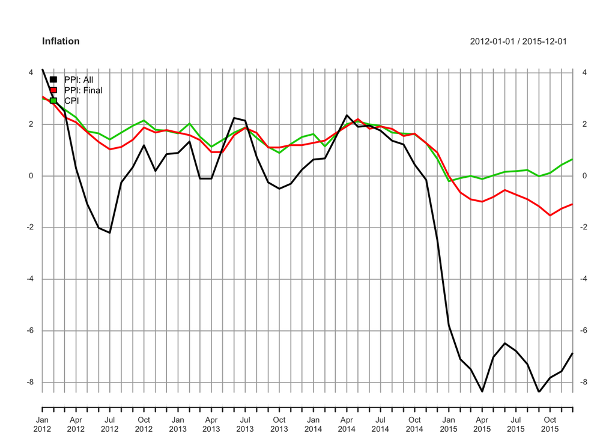

```r
ppi = getSymbols('PPIACO',src='FRED',auto.assign=FALSE)
ppif = getSymbols('PPIFIS',src='FRED',auto.assign=FALSE)
cpi = getSymbols('CPIAUCSL',src='FRED',auto.assign=FALSE)

# calculate yoy inflation rate
pi.ppi = (ppi/lag(ppi,12)-1)*100
pi.ppif = (ppif/lag(ppif,12)-1)*100
pi.cpi = (cpi/lag(cpi,12)-1)*100

data = cbind(pi.ppi,pi.ppif,pi.cpi)
colnames(data) <- c("PPI: All","PPI: Final","CPI")

t = "2012-01-01/2015-12-01" # plot inflation from 2012-01 to 2015-12

plot(data[t],legend.loc='topleft',auto.legend=TRUE,main="Inflation")
```

### 4.2

PPI: All is more volatile. PPI: Final tracks CPI better.

### 4.3

Rising housing cost (shelter price) in 2015 contributes to CPI but not PPI.

### 4.4

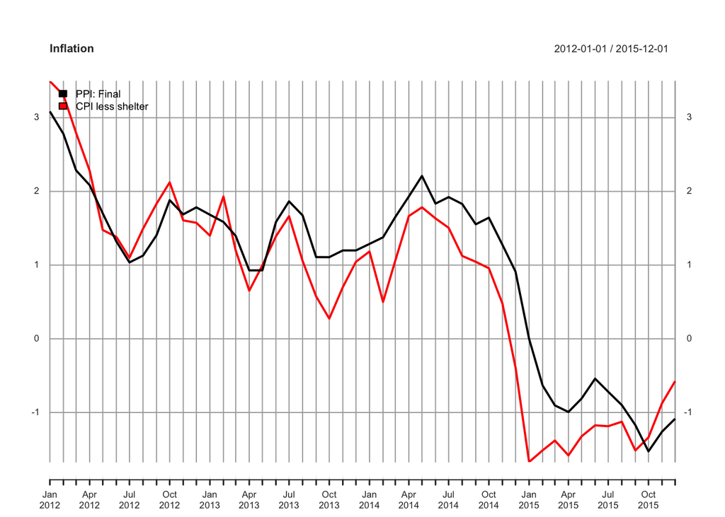

```r
cpiLessShelter = getSymbols('CUSR0000SA0L2',src='FRED',auto.assign=FALSE)
pi.cpiLessShelter = (cpiLessShelter/lag(cpiLessShelter,12)-1)*100

data = cbind(pi.ppif,pi.cpiLessShelter)
colnames(data) <- c("PPI: Final","CPI less shelter")

t = "2012-01-01/2015-12-01" # plot inflation from 2012-01 to 2015-12

plot(data[t],legend.loc='topleft',auto.legend=TRUE,main="Inflation")
```

### 4.5

faster; Reason: Housing has a larger weight in the CPI basket than in the PCEPI.

[^1]: $14000 = 20\times200 + 1000\times10$
[^2]: $13500=35\times100+ 500\times20$
[^3]: $16570.4=22000\times\mathcal{Q}_{2000,2002}^{C}$
[^4]: $15932.02=12000\times\mathcal{Q}_{2002,2000}^{C}=\frac{12000}{\mathcal{Q}_{2000,2002}^{C}}$
[^5]: $13428.83=12000\times\mathcal{Q}_{2002,2001}^{C}=\frac{12000}{\mathcal{Q}_{2001,2002}^{C}}=\frac{12000}{\mathcal{Q}_{2001,2002}^{F}}$